# R Notebook

### Affirmative_asylum_Refugee_count

### Defensive_asylum_Refugee_count

### Refugee_status_asylum_count

### Affirmative_asylum_Refugee_count

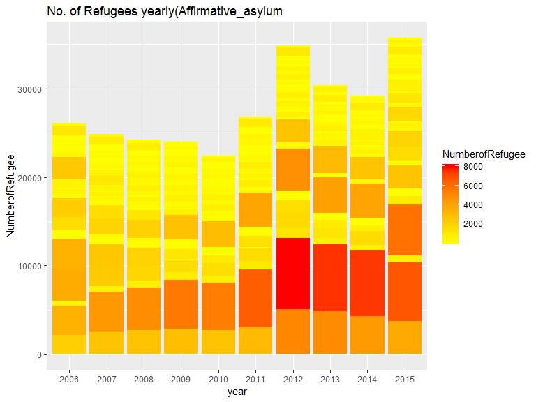

### Defensive_asylum_Refugee_count

### Refugee_status_asylum_count

## Refugees Count in America

### America

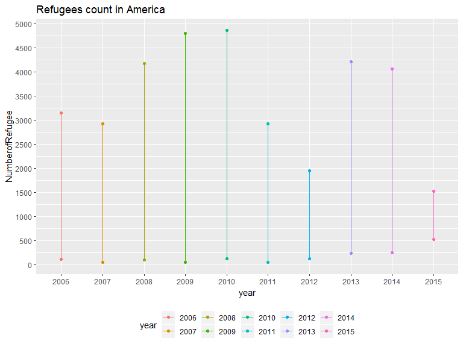

### North America

# Motivation

With the recent news this week of stengthening the U.S immigration laws, I wanted to have a look at the history/numbers related to this matter. Although this dataset is not directly related to U.S immigration, it might offer some insights about the location of people seeking asylum to the U.S.

From a visualization point of view, the goal is to make, per year :

- a map to show the populations movement (end-point will be the U.S.)
- an histogram with the Total numbers of Refugees per Continent

# Data preparation

- convert the numbers in the dataset from characters to numeric
- take care of special cases : `-`, `,` and other characters : `D`, `X`
- re-arrange the dataframe for easy plotting

|  | Continent.Country.of.Nationality | variable | value |
| --- | --- | --- | --- |
| 1 | Africa | Y2006 | 18129 |
| 2 | Asia | Y2006 | 10086 |
| 3 | Europe | Y2006 | 9615 |
| 4 | North America | Y2006 | 3145 |
| 5 | Oceania | Y2006 | 0 |
| 6 | South America | Y2006 | 119 |

# Preparing maps, plots

## Group_by `Continent`

This will be the histogram per Continent

## Preparing the map

|  | countries_name | long | lat |
| --- | --- | --- | --- |
| 1 | Afghanistan | 67.70995 | 3.93911 |
| 2 | Angola | 17.87389 | -11.20269 |
| 3 | Armenia | 45.03819 | 40.06910 |
| 4 | Azerbaijan | 47.57693 | 40.14310 |
| 5 | Belarus | 27.95339 | 53.70981 |
| 6 | Bhutan | 90.43360 | 27.51416 |

[output not shown]

## Making map and histograms

For each year :

- merge the data per country that has the breakdown per county with the dataset having the countries geolocations
- calculate the percentage for each country
- prepare the map plot (aesthetic) and save it into a list
- make the histogram plot per Continent

```
[1] 10
```

- Countries from Asia is the major contribution
- the large increase between starting in `2008` for countries in Asia is due to the offer of the US to take 60 000 refugees as part of the `Core Group on Bhutanese Refugees in Nepal` formed by the UNHCR [wikipedia](https://en.wikipedia.org/wiki/Bhutanese_refugees)
- since `2008`, the number of refugees has been ~ 60000/ year
- there is a decrease in the number of refugees from Europe since 2006

# Results (breakdown per Year)

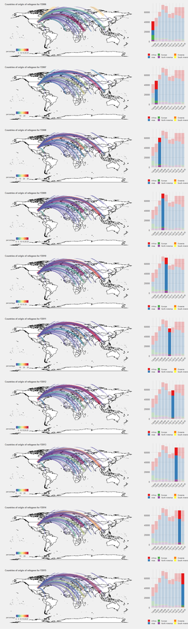

# Results (all years)

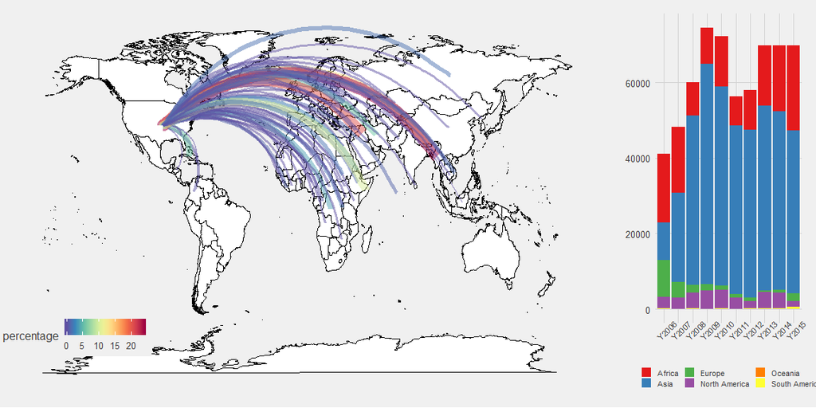